# Cohort and Retention Analysis

Dao Thu Ha & Nguyen Minh Thanh

March 15, 2017

# 1 Định nghĩa

Phân tích Cohort là phân tích một nhóm có những đặc điểm hoặc hành vi chung trong một khoảng thời gian nhất định để xem xét hành vi của nhóm đó.

Trên thực tế tập khách hàng sẽ bao gồm nhiều nhóm, khách hàng cũ ( tỉ lệ duy trì cao hơn), khách hàng mới ( tỉ lệ duy trì thấp hơn), vì vậy để tìm hiểu nguyên nhân tại sao tỉ lệ duy trì thấp hoặc biến động nhiều, chúng ta sẽ không thực sự biết được tỷ lệ duy trì bị ảnh hưởng bởi nhóm khách hàng nào.

Có 2 cách để chia tập khách hàng cho phân tích corhort:

Acquisition cohorts: Chia tập khách hàng theo ngày khác hàng đăng kí/ sử dụng. Ví dụ với khách hàng I2B, chúng ta có thể chia thao ngày khách hàng bắt đầu kích hoạt tài khoản. Bằng cách chia tập khách hàng theo phương pháp này, chúng ta có thể biết được khách hàng tiếp tục duy trì sử dụng sản phẩm bao lâu tính từ ngày bắt đầu sử dụng.

Behavioral cohorts: Chia tập khách hàng theo hành vi của người dùng trong 1 khoảng thời gian nhất định, đây có thể là bất kì hoạt động nào mà khách hàng thực hiện như giao dịch đầu tiên trên Ecommerce, thức hiện mở thẻ qua 1 chương trình khuyến mại.Cohort sẽ là 1 nhóm khách hàng thực hiện các hành động đó trong 1 khoảng thời gian nhất định. Từ đó chúng ta có thể so sánh các nhóm có behavior khác nhau có tỉ lệ duy trì như thế nào.

Ví dụ:

Nhóm khách hàng theo yếu tố là tháng có phát sinh giao dịch thẻ credit đầu tiên. Như vậy những khách hàng có giao dịch thẻ lần đầu trong tháng 01 /2016 sẽ thuộc Cohort tháng 1, tương tự với khách hàng có giao dịch lần đầu vào tháng 02/2016, 03/2016

# 2 Các khái niệm cơ bản

## 2.1 Cohort table

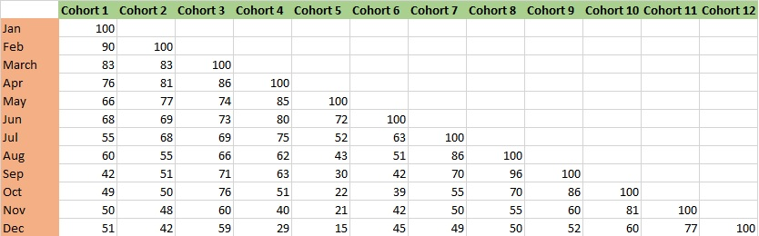

Phía bên tay trái là tháng bắt đầu giao dịch thẻ đầu tiên, hàng đầu là các nhóm Cohort, được nhóm theo tháng mà khách hàng bắt đầu sử dụng thẻ Credit card. Dữ liệu trong bảng là tỉ lệ % duy trì của khách hàng.

## 2.2 Các câu hỏi liên quan đến Cohort

Khi sử dụng Corhort, có 4 câu hỏi thường gặp về mặt kinh doanh cần phải trả lời là:

1. Tỉ lệ duy trì của khác hàng như thế nào?
2. Thời điểm nào chúng ta để mất khách hàng nhiều nhất?
3. Tỷ lệ tại thời điểm chúng ta để mất khách hàng nhiều nhất có tiến bộ qua thời gian không?
4. Tỉ lệ retention rate giữa các nhóm có behavior khác nhau như thế nào?

# 3 Cách thực hiện Cohort trên R

## 3.1 Cohort ( không trùng lặp)

Dữ liệu test sử dụng giao dịch thẻ tín dụng của khách hàng, khách hàng được chia theo 3 nhóm chính: typical users, high frequency, attritor & high risk.

Ta sẽ theo dõi tỉ lệ duy trì của nhóm này. Trong mỗi nhóm, sẽ group khác hàng theo tháng thực hiện giao dịch thẻ đầu tiên.

```r
# Data for high risk group
oo <- transaction.data.201701 %>%
  filter(new.segment == "high risk" )
```

### 3.1.1 Step 1: Tạo Cohort table, Tính số lượng duy trì cho mỗi nhóm Cohort

**1.Tính số tháng ( Trans month) từ thời điểm Current Transaction date đến Min Transaction date của tập Dữ liệu**

```r
# Transofrm transaction date to Date type:
oo$trans_date <- as.Date(oo$trans_date)

#
oo$trans_month <- elapsed_months((oo$trans_date), min(oo$trans_date))

oo$trans_month <- oo$trans_month + 1
```

**2. Tạo bảng dữ liệu bao gồm 2 trường thông tin : CIF và Trans month**

```r
aa <- oo %>%
  select(trans_month,target_id)

aa <- aa %>% distinct(trans_month,target_id)
```

**3. Tạo Cohort table, tính số lượng khách hàng cho mỗi nhóm Cohort và số lượng khách hàng duy trì**

Tạo 1 DF chỉ có 1 trường là số tháng tính từ tháng giao dịch đầu tiên của tập dữ liệu.

Object 1: Những CIF có trans_month = i ( ví dụ 10)

Object 2: Những CIF có trans_month từ 1 đến i-1 ( CIF có trong trans_month từ 1 đến 9)

Object 3: Transaction của những CIF ở trong Object 1 nhưng không ở trong Object 2 –> Số lượng khách hàng thuộc nhóm Corhort i ( Corhort 10). Từ đó group theo Trans month để tính số lượng khách hàng duy trì của nhóm đó.

Map số lượng khách hàng từ Object 3 với bảng DF để ra Cohort table ( Trans_month 10 là tổng số lượng khách hàng có giao dịch đầu tiên trong thán thứ 10, Trans_month 11 là số lượng khách hàng cohort 10 tiếp tục có giao dịch tại tháng thứ 11)

```r
# Vòng lặp tính cohort:
df1 <- aa %>%
  select(trans_month) %>%
  distinct %>%
  arrange(trans_month) %>%
  as.data.frame()

for (i in 1:60){
  c <-   aa %>%
    filter(trans_month == i)
  t <-   aa %>%
    filter(trans_month %in% c(1:i-1))
  d <- aa %>%
    filter(target_id %in% c$target_id) %>%
    filter(!target_id %in% t$target_id) %>%
    distinct(target_id,trans_month) %>%
    group_by(trans_month) %>%
    count
  e <- df1 %>% ncol + 1
  df1$e <- 0
  names(df1)[ncol(df1)] <- paste0("cohort.", i)
  df1[df1$trans_month %in% d$trans_month,ncol(df1)] <- d$n
}

df1
```

```
##    trans_month cohort.1 cohort.2 cohort.3 cohort.4 cohort.5 cohort.6
## 1            1        1        0        0        0        0        0
## 2            3        0        0        1        0        0        0
## 3            4        0        0        0        1        0        0
## 4            5        0        0        0        1      308        0
## 5            6        1        0        0        1      219      737
## 6            7        0        0        0        1      200      387
## 7            8        0        0        1        0      199      410
## 8            9        1        0        1        1      182      390
## 9           10        1        0        0        1      177      373
## 10          11        1        0        0        1      161      369
## 11          12        1        0        0        0      153      349
## 12          13        0        0        0        0      151      334
## 13          14        1        0        0        1      149      331
## 14          15        1        0        0        1      133      295
```

[output cut: 525 more lines]

### 3.1.2 Step 2 : Tạo Cohort table, Tính tỉ lệ % duy trì cho mỗi nhóm Cohort

```r
# Vòng lặp tính percentage:
df2 <- aa %>%
  select(trans_month) %>%
  distinct %>%
  arrange(trans_month) %>%
  as.data.frame()

for (i in 1:60){
  c <-   aa %>%
    filter(trans_month == i)
  t <-   aa %>%
    filter(trans_month %in% c(1:i-1))
  d <- aa %>%
    filter(target_id %in% c$target_id) %>%
    filter(!target_id %in% t$target_id) %>%
    filter(!(trans_month %in% c(1:i-1))) %>%
    distinct(target_id,trans_month) %>%
    group_by(trans_month) %>%
    count %>% as.data.frame()
  d$prop <- d$n/d[1,2]
  e <- df2 %>% ncol + 1
  df2$e <- 0
  names(df2)[ncol(df2)] <- paste0("cohort.", i)
  df2[df2$trans_month %in% d$trans_month,ncol(df2)] <- d$prop
}

df2[2,3] <- 1
df2
```

```
##    trans_month cohort.1 cohort.2 cohort.3 cohort.4    cohort.5    cohort.6
## 1            1        1        0        0        0 0.000000000 0.000000000
## 2            3        0        1        1        0 0.000000000 0.000000000
## 3            4        0        0        0        1 0.000000000 0.000000000
## 4            5        0        0        0        1 1.000000000 0.000000000
## 5            6        1        0        0        1 0.711038961 1.000000000
## 6            7        0        0        0        1 0.649350649 0.525101764
## 7            8        0        0        1        0 0.646103896 0.556309362
## 8            9        1        0        1        1 0.590909091 0.529172320
## 9           10        1        0        0        1 0.574675325 0.506105834
## 10          11        1        0        0        1 0.522727273 0.500678426
## 11          12        1        0        0        0 0.496753247 0.473541384
## 12          13        0        0        0        0 0.490259740 0.453188602
## 13          14        1        0        0        1 0.483766234 0.449118046
## 14          15        1        0        0        1 0.431818182 0.400271370
```

[output cut: 585 more lines]

### 3.1.3 Step 3: Vẽ retention curve

**1. Tính tỉ lệ retention tại từng group trans_month**

```r
# Tính retention:
df3 <- melt(df2, id.vars = c("trans_month"))

df4 <- df3 %>%
  mutate(index = str_sub(variable, 8, str_length(variable)))

df4$index <- as.numeric(df4$index)

df4 <- df4 %>%
  filter(trans_month >= index) %>%
                      group_by(variable)

df5 <- df4 %>%
  group_by(variable) %>%
    mutate(group = trans_month - min(trans_month)) %>%
        group_by(group)


df6 <- df5 %>%
    summarise(retention.rate = mean(value))

reten.attritor <- df6
reten.attritor
```

```
## # A tibble: 60 × 2
##    group retention.rate
##    <dbl>          <dbl>
## 1      0      1.0000000
## 2      1      0.4736391
## 3      2      0.3980870
## 4      3      0.3535129
## 5      4      0.3050836
## 6      5      0.3383941
## 7      6      0.3048751
## 8      7      0.2766022
## 9      8      0.2556207
## 10     9      0.2414430
## # ... with 50 more rows
```

**2. Vẽ retention curve**

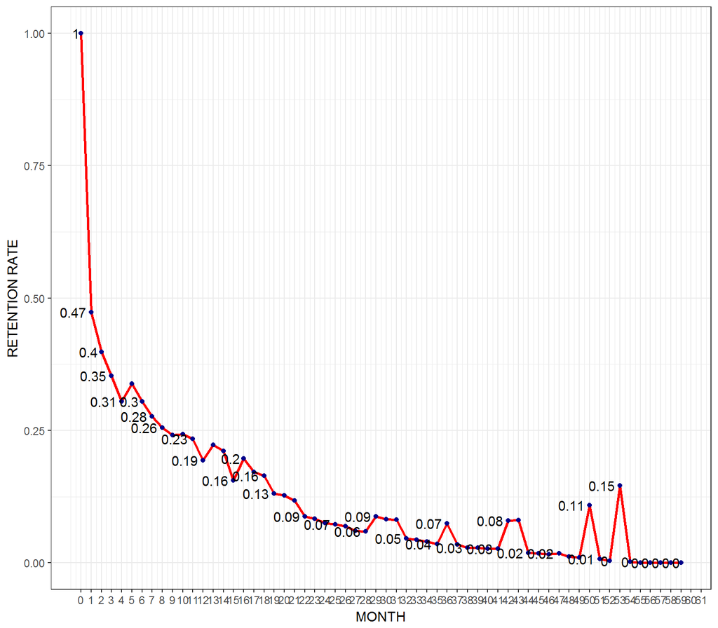

```r
# Vẽ đường retention:
reten.attritor %>%
  ggplot(aes(group,retention.rate)) +
    geom_line(col = "red", size = 1) +
    geom_point(col = "darkblue") +
    geom_text(aes(label = round(retention.rate,2)), check_overlap = TRUE, hjust = 1.2) +
    scale_x_continuous(breaks = c(seq(0,63))) +
    labs( x = "MONTH", y = "RETENTION RATE") +
   theme_bw()
```

### 3.1.4 Tổng quát

Thực hiện các steps tương tự với nhóm High frequency và nhóm Typical User.

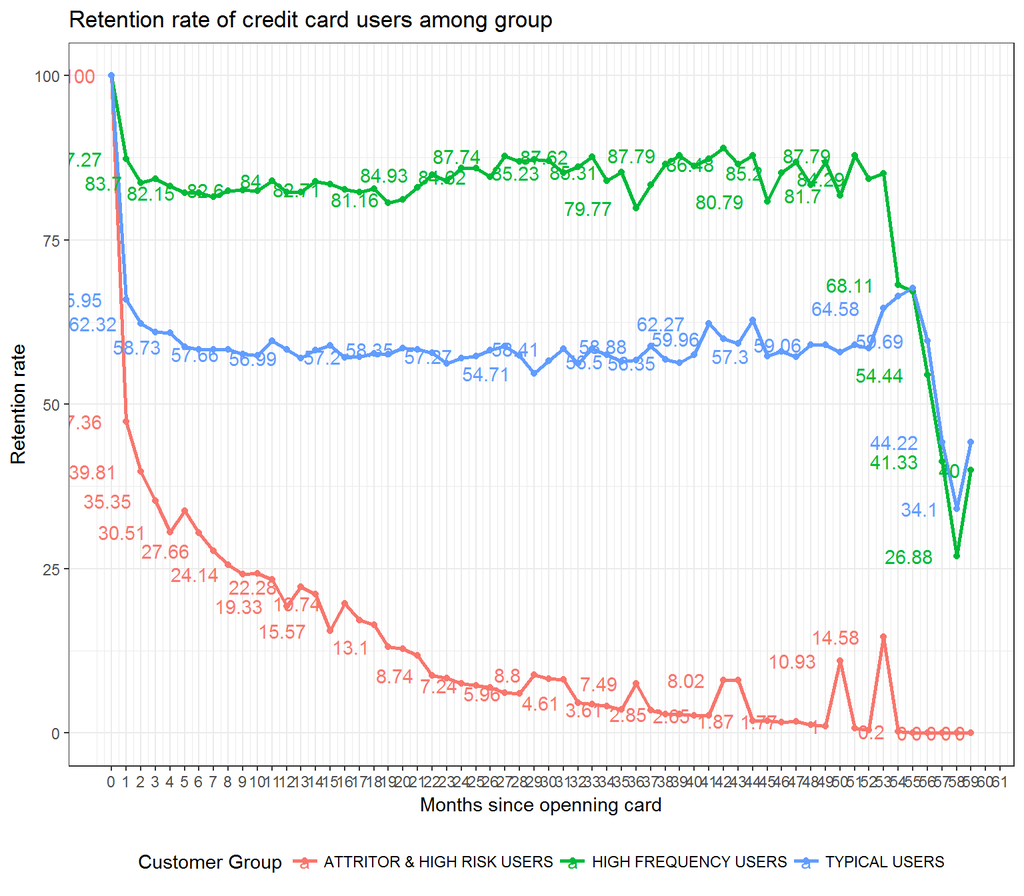

```r
# High frequency:
# Data cho cohort:
oo <- transaction.data.201701 %>%
  filter(new.segment == "high requency" )

# Sửa data:
oo$trans_date <- as.Date(oo$trans_date)
oo$trans_month <- elapsed_months((oo$trans_date), min(oo$trans_date))
oo$trans_month <- as.numeric(oo$trans_month)
oo$trans_month <- ifelse(oo$trans_month <10,str_sub(oo$trans_month, 1,1),
                               str_sub(oo$trans_month, 1, 2))
oo$trans_month <- as.numeric(oo$trans_month)
oo$trans_month <- oo$trans_month + 1


aa <- oo %>%
  select(trans_month,target_id)
# Data sau khi distinct:
aa <- aa %>% distinct(trans_month,target_id)


# Vòng lặp tính cohort:
df1 <- c(1:62) %>% as.data.frame()
names(df1)[1] <- paste("trans_month")
for (i in 1:62){
  c <-   aa %>%
    filter(trans_month == i)
  t <-   aa %>%
    filter(trans_month %in% c(1:i-1))
  d <- aa %>%
    filter(target_id %in% c$target_id) %>%
    filter(!target_id %in% t$target_id) %>%
    distinct(target_id,trans_month) %>%
    group_by(trans_month) %>%
    count
  e <- df1 %>% ncol + 1
  df1$e <- 0
  names(df1)[ncol(df1)] <- paste0("cohort.", i)
  df1[df1$trans_month %in% d$trans_month,ncol(df1)] <- d$n
}


## Vòng lặp tính percentage:

# Vòng lặp tính percentage:
df2 <- c(1:62) %>% as.data.frame()
names(df2)[1] <- paste("trans_month")
for (i in 1:62){
  c <-   aa %>%
    filter(trans_month == i)
  t <-   aa %>%
    filter(trans_month %in% c(1:i-1))
  d <- aa %>%
    filter(target_id %in% c$target_id) %>%
    filter(!target_id %in% t$target_id) %>%
    filter(!(trans_month %in% c(1:i-1))) %>%
    distinct(target_id,trans_month) %>%
    group_by(trans_month) %>%
    count %>% as.data.frame()
  d$prop <- d$n/d[1,2]
  e <- df2 %>% ncol + 1
  df2$e <- 0
  names(df2)[ncol(df2)] <- paste0("cohort.", i)
  df2[df2$trans_month %in% d$trans_month,ncol(df2)] <- d$prop
}
df2[4,5] <- 1

## Tính retention:


# Tính retention:
df3 <- melt(df2, id.vars = c("trans_month"))
df4 <- df3 %>%
  mutate(index = str_sub(variable, 8, str_length(variable)))
df4$index <- as.numeric(df4$index)
df4 <- df4 %>%
  filter(trans_month >= index) %>%
  group_by(variable)
df5 <- df4 %>%
  group_by(variable) %>%
  mutate(group = trans_month - min(trans_month)) %>%
  group_by(group)
df6 <- df5%>% summarise(retention.rate = mean(value))
reten.high.frequency <- df6

# Typical users:
# Data cho cohort:
oo <- transaction.data.201701 %>%
  filter(new.segment == "typical users" )

# Sửa data:
oo$trans_date <- as.Date(oo$trans_date)
oo$trans_month <- elapsed_months((oo$trans_date), min(oo$trans_date))
oo$trans_month <- as.numeric(oo$trans_month)
oo$trans_month <- ifelse(oo$trans_month <10,str_sub(oo$trans_month, 1,1),
                               str_sub(oo$trans_month, 1, 2))
oo$trans_month <- as.numeric(oo$trans_month)
oo$trans_month <- oo$trans_month + 1



aa <- oo %>%
  select(trans_month,target_id)
# Data sau khi distinct:
aa <- aa %>% distinct(trans_month,target_id)


# Vòng lặp tính cohort:
df1 <- c(1:62) %>% as.data.frame()
names(df1)[1] <- paste("trans_month")
for (i in 1:62){
  c <-   aa %>%
    filter(trans_month == i)
  t <-   aa %>%
    filter(trans_month %in% c(1:i-1))
  d <- aa %>%
    filter(target_id %in% c$target_id) %>%
    filter(!target_id %in% t$target_id) %>%
    distinct(target_id,trans_month) %>%
    group_by(trans_month) %>%
    count
  e <- df1 %>% ncol + 1
  df1$e <- 0
  names(df1)[ncol(df1)] <- paste0("cohort.", i)
  df1[df1$trans_month %in% d$trans_month,ncol(df1)] <- d$n
}



## Vòng lặp tính percentage:


# Vòng lặp tính percentage:
df2 <- c(1:62) %>% as.data.frame()
names(df2)[1] <- paste("trans_month")
for (i in 1:62){
  c <-   aa %>%
    filter(trans_month == i)
  t <-   aa %>%
    filter(trans_month %in% c(1:i-1))
  d <- aa %>%
    filter(target_id %in% c$target_id) %>%
    filter(!target_id %in% t$target_id) %>%
    filter(!(trans_month %in% c(1:i-1))) %>%
    distinct(target_id,trans_month) %>%
    group_by(trans_month) %>%
    count %>% as.data.frame()
  d$prop <- d$n/d[1,2]
  e <- df2 %>% ncol + 1
  df2$e <- 0
  names(df2)[ncol(df2)] <- paste0("cohort.", i)
  df2[df2$trans_month %in% d$trans_month,ncol(df2)] <- d$prop
}

# Tính retention:
df3 <- melt(df2, id.vars = c("trans_month"))
df4 <- df3 %>%
  mutate(index = str_sub(variable, 8, str_length(variable)))
df4$index <- as.numeric(df4$index)
df4 <- df4 %>%
  filter(trans_month >= index) %>%
  group_by(variable)
df5 <- df4 %>%
  group_by(variable) %>%
  mutate(group = trans_month - min(trans_month)) %>%
  group_by(group)
df6 <- df5%>% summarise(retention.rate = mean(value))
reten.typical.users <- df6

names(reten.attritor)[2] <- paste("ATTRITOR & HIGH RISK USERS")
names(reten.high.frequency)[2] <- paste("HIGH FREQUENCY USERS")
names(reten.typical.users)[2] <- paste("TYPICAL USERS")

final <- left_join(reten.attritor, reten.high.frequency, by = "group")
final <- left_join(final, reten.typical.users, by = "group")

final1 <- final %>%
  melt(id.vars = c("group"))

final2 <- final1

final2$value <- final2$value*100

final2 %>%
  ggplot(aes(group,value, col = variable)) +
  geom_line(size = 1) +
  geom_point() +
  geom_text(aes(label = round(value,2)), check_overlap = TRUE, hjust = 1.5) +
  scale_x_continuous(breaks = c(seq(0,61))) +
  labs( x = "Months since openning card", y = "Retention rate") +
  theme_bw() +
  scale_color_discrete(name = "Customer Group") +
  theme(legend.position = "bottom") +
  ggtitle("Retention rate of credit card users among group")
```

## 3.2 Cohort ( trùng lặp)

### 3.2.1 Step 1: Tạo Cohort table, Tính số lượng duy trì cho mỗi nhóm Cohort

```r
# Data cho cohort:
oo <- transaction.data.201701 %>%
  filter(new.segment == "high risk" ) %>%
  filter(trans_date >= as.Date("2015-01-01"))
```

**1.Tính số tháng từ thời điểm Current Transaction date đến Min Transaction date của tập Dữ liệu**

```r
# Sửa data:
oo$trans_date <- as.Date(oo$trans_date)
oo$trans_month <- elapsed_months((oo$trans_date), min(oo$trans_date))
oo$trans_month <- as.numeric(oo$trans_month)
oo$trans_month <- ifelse(oo$trans_month <10,str_sub(oo$trans_month, 1,1),
                         str_sub(oo$trans_month, 1, 2))
oo$trans_month <- as.numeric(oo$trans_month)
oo$trans_month <- oo$trans_month + 1
```

**2. Tạo bảng dữ liệu bao gồm 2 trường thông tin : CIF và Trans month**

```r
aa <- oo %>%
  select(trans_month,target_id)
```

**3. Tạo Cohort table, tính số lượng khách hàng cho mỗi nhóm Cohort và số lượng khách hàng duy trì**

Tạo 1 DF chỉ có 1 trường là số tháng tính từ tháng giao dịch đầu tiên của tập dữ liệu.

Object 1: Những CIF có trans_month = i ( ví dụ 10)

Object 2: Filter những CIF ở trong Object 1 và trans_month có giá trị từ i trở đi.Group theo trans_month để có số lượng khách hàng thực hiện transactions tại tháng i–> Cohort 10

Map số lượng khách hàng từ Object 2 với bảng DF để ra Cohort table ( Trans_month 10 là tổng số lượng khách hàng có giao dịch đầu tiên trong thán thứ 10, Trans_month 11 là số lượng khách hàng cohort 10 tiếp tục có giao dịch tại tháng thứ 11)

```r
df1 <- aa %>%
  select(trans_month) %>%
  distinct %>%
  arrange(trans_month) %>%
  as.data.frame()

for (i in 1:20){
  c <-   aa %>%
    filter(trans_month == i)
  d <- aa %>%
    filter(target_id %in% c$target_id) %>%
    filter(!(trans_month %in% c(1:i-1))) %>%
    distinct(target_id,trans_month) %>%
    group_by(trans_month) %>%
    count
  e <- df %>% ncol + 1
  df1$e <- 0
  names(df1)[ncol(df1)] <- paste0("cohort.", i)
  df1[df1$trans_month %in% d$trans_month,ncol(df1)] <- d$n
}
df1
```

```
##    trans_month cohort.1 cohort.2 cohort.3 cohort.4 cohort.5 cohort.6
## 1            1      331        0        0        0        0        0
## 2            2      294     7731        0        0        0        0
## 3            3      228     4391     7413        0        0        0
## 4            4      222     4022     4323     7254        0        0
## 5            5      196     3586     3835     4391     7498        0
## 6            6      184     3330     3412     3906     4514     7627
## 7            7      162     2833     2962     3295     3792     4353
## 8            8      151     2666     2740     3048     3414     3845
## 9            9      137     2318     2394     2649     2983     3269
## 10          10      121     2007     2067     2318     2551     2854
## 11          11       93     1911     1963     2177     2425     2671
## 12          12       91     1739     1748     1951     2179     2351
## 13          13       87     1520     1581     1738     1914     2125
## 14          14       68     1317     1368     1483     1664     1830
```

[output cut: 48 more lines]

### 3.2.2 Step 2 : Tạo Cohort table, Tính tỉ lệ % duy trì cho mỗi nhóm Cohort

```r
# Tính percentage của cohort:
df2 <- aa %>%
  select(trans_month) %>%
  distinct %>%
  arrange(trans_month) %>%
  as.data.frame()

for (i in 1:20){
  a <-   aa %>%
    filter(trans_month == i)
  b <- aa %>%
    filter(target_id %in% a$target_id) %>%
    filter(!(trans_month %in% c(1:i-1))) %>%
    distinct(target_id,trans_month) %>%
    group_by(trans_month) %>%
    count %>%
    data.frame()
  b$prop <- b$n/b[1,2]*100
  e <- df2 %>% ncol + 1
  df2$e <- 0
  names(df2)[ncol(df2)] <- paste0("cohort.", i)
  df2[df2$trans_month %in% b$trans_month,ncol(df2)] <- b$prop
}
df2
```

```
##    trans_month   cohort.1   cohort.2   cohort.3   cohort.4   cohort.5
## 1            1 100.000000   0.000000   0.000000   0.000000   0.000000
## 2            2  88.821752 100.000000   0.000000   0.000000   0.000000
## 3            3  68.882175  56.797310 100.000000   0.000000   0.000000
## 4            4  67.069486  52.024318  58.316471 100.000000   0.000000
## 5            5  59.214502  46.384685  51.733441  60.532120 100.000000
## 6            6  55.589124  43.073341  46.027249  53.846154  60.202721
## 7            7  48.942598  36.644677  39.956833  45.423215  50.573486
## 8            8  45.619335  34.484543  36.962094  42.018197  45.532142
## 9            9  41.389728  29.983185  32.294618  36.517783  39.783942
## 10          10  36.555891  25.960419  27.883448  31.954784  34.022406
## 11          11  28.096677  24.718665  26.480507  30.011028  32.341958
## 12          12  27.492447  22.493856  23.580197  26.895506  29.061083
## 13          13  26.283988  19.661105  21.327398  23.959195  25.526807
## 14          14  20.543807  17.035312  18.454067  20.443893  22.192585
```

[output cut: 69 more lines]

### 3.2.3 Step 3: Vẽ retention curve

**1. Tính tỉ lệ retention tại từng group trans_month**

```r
# Tính retention:
df3 <- melt(df2, id.vars = c("trans_month"))
df4 <- df3 %>%
  mutate(index = str_sub(variable, 8, str_length(variable)))
df4$index <- as.numeric(df4$index)
df4 <- df4 %>%
  filter(trans_month >= index) %>%
  group_by(variable)
df5 <- df4 %>%
  group_by(variable) %>%
  mutate(group = trans_month - min(trans_month)) %>%
  group_by(group)
df6 <- df5%>% summarise(retention.rate = mean(value))
reten.attritor <- df6
```

**2. Vẽ đường retention**

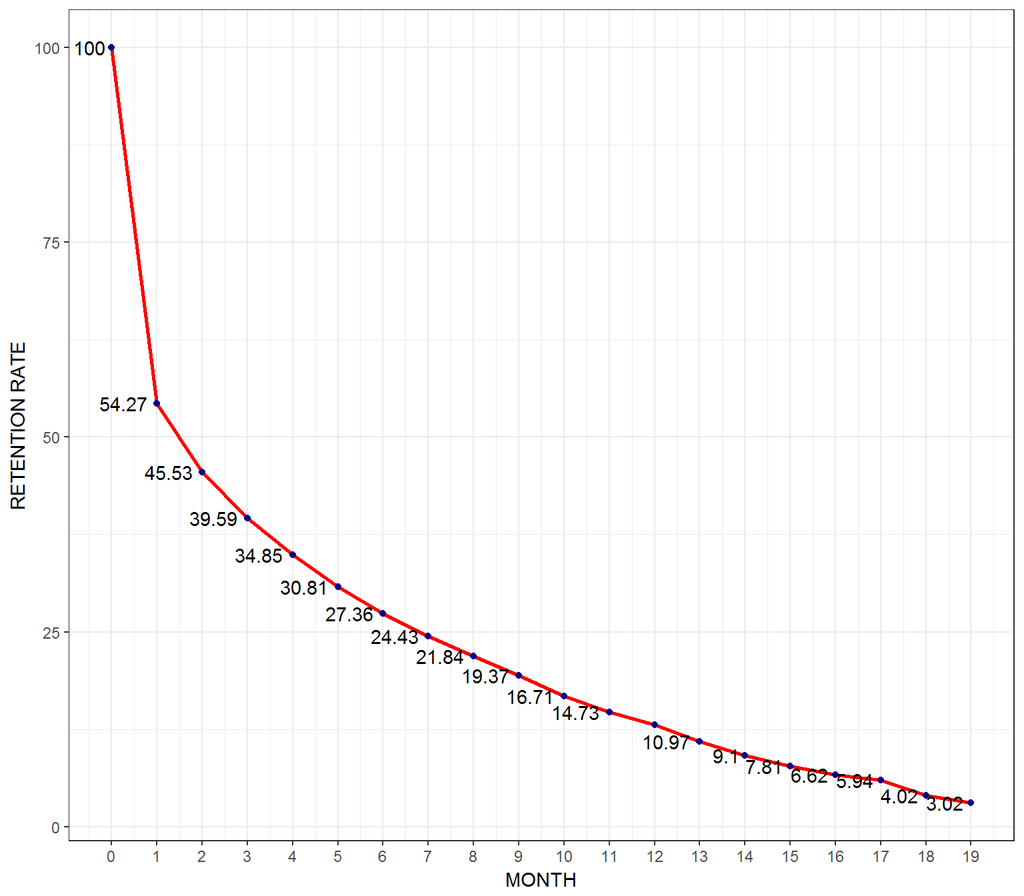

```r
# Vẽ đường retention:
reten.attritor %>% ggplot(aes(group,retention.rate)) +
  geom_line(col = "red", size = 1) +
  geom_point(col = "darkblue") +
  geom_text(aes(label = round(retention.rate,2)), check_overlap = TRUE, hjust = 1.2) +
  scale_x_continuous(breaks = c(seq(0,63))) +
  labs( x = "MONTH", y = "RETENTION RATE") +
  theme_bw()
```

### 3.2.4 Tổng quát

Thực hiện các step tương tự với nhóm High frequency và nhóm Typical User.

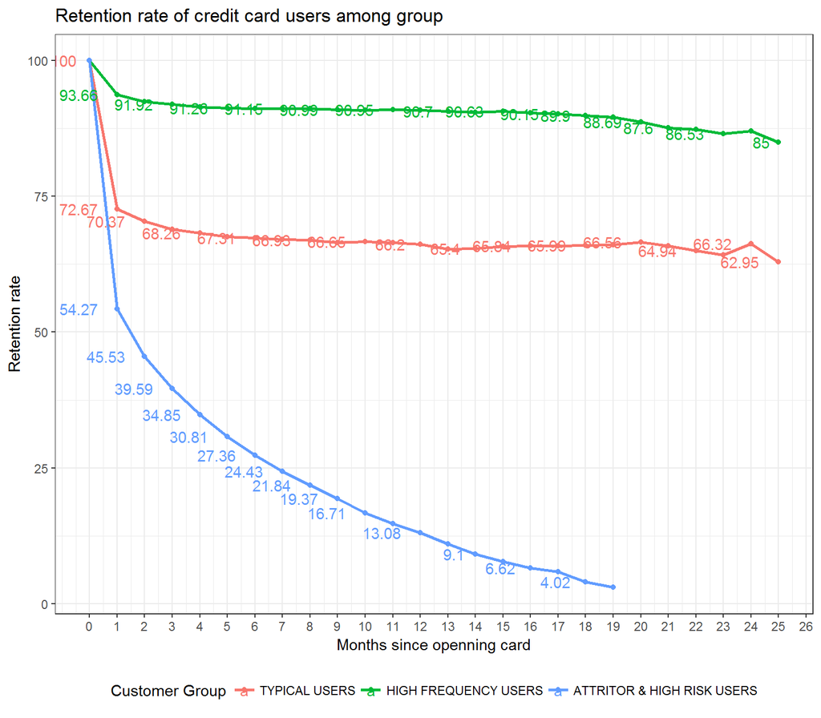

```r
# High frequency:
# Data cho cohort:
oo <- transaction.data.201701 %>%
  filter(new.segment == "high requency" ) %>%
  filter(trans_date >= as.Date("2015-01-01"))

# Sửa data:
oo$trans_date <- as.Date(oo$trans_date)
oo$trans_month <- elapsed_months((oo$trans_date), min(oo$trans_date))
oo$trans_month <- as.numeric(oo$trans_month)
oo$trans_month <- ifelse(oo$trans_month <10,str_sub(oo$trans_month, 1,1),
                         str_sub(oo$trans_month, 1, 2))
oo$trans_month <- as.numeric(oo$trans_month)
oo$trans_month <- oo$trans_month + 1


aa <- oo %>%
  select(trans_month,target_id)

df1 <- aa %>%
  select(trans_month) %>%
  distinct %>%
  arrange(trans_month) %>%
  as.data.frame()

for (i in 1:26){
  c <-   aa %>%
    filter(trans_month == i)
  d <- aa %>%
    filter(target_id %in% c$target_id) %>%
    filter(!(trans_month %in% c(1:i-1))) %>%
    distinct(target_id,trans_month) %>%
    group_by(trans_month) %>%
    count
  e <- df %>% ncol + 1
  df1$e <- 0
  names(df1)[ncol(df1)] <- paste0("cohort.", i)
  df1[df1$trans_month %in% d$trans_month,ncol(df1)] <- d$n
}

# Tính percentage của cohort:
df2 <- aa %>%
  select(trans_month) %>%
  distinct %>%
  arrange(trans_month) %>%
  as.data.frame()

for (i in 1:26){
  a <-   aa %>%
    filter(trans_month == i)
  b <- aa %>%
    filter(target_id %in% a$target_id) %>%
    filter(!(trans_month %in% c(1:i-1))) %>%
    distinct(target_id,trans_month) %>%
    group_by(trans_month) %>%
    count %>%
    data.frame()
  b$prop <- b$n/b[1,2]*100
  e <- df2 %>% ncol + 1
  df2$e <- 0
  names(df2)[ncol(df2)] <- paste0("cohort.", i)
  df2[df2$trans_month %in% b$trans_month,ncol(df2)] <- b$prop
}
# Tính retention:
df3 <- melt(df2, id.vars = c("trans_month"))
df4 <- df3 %>%
  mutate(index = str_sub(variable, 8, str_length(variable)))
df4$index <- as.numeric(df4$index)
df4 <- df4 %>%
  filter(trans_month >= index) %>%
  group_by(variable)
df5 <- df4 %>%
  group_by(variable) %>%
  mutate(group = trans_month - min(trans_month)) %>%
  group_by(group)
df6 <- df5%>% summarise(retention.rate = mean(value))
reten.high.frequency <- df6

# typical users:
# Data cho cohort:
oo <- transaction.data.201701 %>%
  filter(new.segment == "typical users" ) %>%
  filter(trans_date >= as.Date("2015-01-01"))
# Sửa data:
oo$trans_date <- as.Date(oo$trans_date)
oo$trans_month <- elapsed_months((oo$trans_date), min(oo$trans_date))
oo$trans_month <- as.numeric(oo$trans_month)
oo$trans_month <- ifelse(oo$trans_month <10,str_sub(oo$trans_month, 1,1),
                         str_sub(oo$trans_month, 1, 2))
oo$trans_month <- as.numeric(oo$trans_month)
oo$trans_month <- oo$trans_month + 1

aa <- oo %>%
  select(trans_month,target_id)

df1 <- aa %>%
  select(trans_month) %>%
  distinct %>%
  arrange(trans_month) %>%
  as.data.frame()

for (i in 1:26){
  c <-   aa %>%
    filter(trans_month == i)
  d <- aa %>%
    filter(target_id %in% c$target_id) %>%
    filter(!(trans_month %in% c(1:i-1))) %>%
    distinct(target_id,trans_month) %>%
    group_by(trans_month) %>%
    count
  e <- df %>% ncol + 1
  df1$e <- 0
  names(df1)[ncol(df1)] <- paste0("cohort.", i)
  df1[df1$trans_month %in% d$trans_month,ncol(df1)] <- d$n
}

# Tính percentage của cohort:
df2 <- aa %>%
  select(trans_month) %>%
  distinct %>%
  arrange(trans_month) %>%
  as.data.frame()

for (i in 1:26){
  a <-   aa %>%
    filter(trans_month == i)
  b <- aa %>%
    filter(target_id %in% a$target_id) %>%
    filter(!(trans_month %in% c(1:i-1))) %>%
    distinct(target_id,trans_month) %>%
    group_by(trans_month) %>%
    count %>%
    data.frame()
  b$prop <- b$n/b[1,2]*100
  e <- df2 %>% ncol + 1
  df2$e <- 0
  names(df2)[ncol(df2)] <- paste0("cohort.", i)
  df2[df2$trans_month %in% b$trans_month,ncol(df2)] <- b$prop
}

# Tính retention:
df3 <- melt(df2, id.vars = c("trans_month"))
df4 <- df3 %>%
  mutate(index = str_sub(variable, 8, str_length(variable)))
df4$index <- as.numeric(df4$index)
df4 <- df4 %>%
  filter(trans_month >= index) %>%
  group_by(variable)
df5 <- df4 %>%
  group_by(variable) %>%
  mutate(group = trans_month - min(trans_month)) %>%
  group_by(group)
df6 <- df5%>% summarise(retention.rate = mean(value))
reten.typical.users <- df6

# Vẽ retention
names(reten.attritor)[2] <- paste("ATTRITOR & HIGH RISK USERS")
names(reten.high.frequency)[2] <- paste("HIGH FREQUENCY USERS")
names(reten.typical.users)[2] <- paste("TYPICAL USERS")

final <- left_join(reten.typical.users, reten.high.frequency, by = "group")
final <- left_join(final, reten.attritor, by = "group")

final1 <- final %>%
  melt(id.vars = c("group"))
final2 <- final1

final2 %>%
  ggplot(aes(group,value, col = variable)) +
  geom_line(size = 1) +
  geom_point() +
  geom_text(aes(label = round(value,2)), check_overlap = TRUE, hjust = 1.5) +
  scale_x_continuous(breaks = c(seq(0,26))) +
  labs( x = "Months since openning card", y = "Retention rate") +
  theme_bw() +
  scale_color_discrete(name = "Customer Group") +
  theme(legend.position = "bottom") +
  ggtitle("Retention rate of credit card users among group")
```